# Documentation of data handling, ReefSYN Working Group

André Luís Luza (Post-Doc of ReefSYN)

18/10/2021

## The data

This document aims to describe modifications in the datasets gathered by the ReefSYN Working Group (all databases are referenced at the end of this document). Modifications were made in order to enable the match of different sources of data – and therefore the integration of data. The original datasets are kept together with modified versions of the dataset (see ReadMe files). Datasets with consolidated modifications have in their file name the sufix "… _updated_ALLuza_v1“.”v1" is used to control the version, so that it can change over time with updates and identification of errors.

At this moment, we handle the data of Morais et al. (2017), Aued et al. (2018, 2019), Longo et al. (2019), Ross et al. (2019), and Francini-Filho et al. (unpublished data). Although most of these data were collected by the same group of researchers, it was possible to identify some inconsistencies regarding: 1) region names; 2) locality names; 3) site names; 4) different IDs of unique sampling events; 5) format of sampling data, month and year; 6) lack of geographical information; 7) incorrect writing of species names; 8) the identity of the most basic sampling unit (e.g., one video plot, photoquadrat) was not readily available. Instead, it was embedded together with the identity of the unique sample IDs (that often combine site, depth observer, device, video ID; e.g., “Cagarras/Fundo_061011_Cam_am_Video1/”; “pml_basil_19abril13_fundo_jpq_gopro3_v1”)

Such inconsistencies occur because repositories of published data did not require that such data follow formatting rules. Also, due to the inconsistencies just listed, the different datasets do not match each other (but we can make it work even after these data are published – under the rights of copy of each dataset). Many sites are shared among the five datasets, which indicate that we can make studies combining/collate different sources of data (it is a method underlying “ecological synthesis”, Ref.).

Previous modifications are listed in the metadata files (format ‘docx’ or ‘rmd’). Some modifications that could not be done in R, regarding the splitting of the sample IDs, were done in Microsoft Excel.

#### Organization in folders

These data are organized in a folder called “Data”. Within it we can find the names of the different datasources. See below a table with all these information.

| Folder.Name | Type.of.file | Data.about | Trait.data | Has.R.script | Original.Data.Name | Modified.Data.Name |
| --- | --- | --- | --- | --- | --- | --- |
| BioOracle | Raster | Environmental layers |  |  | BO_*.tif | — |
| brazil-coastline | Spatial lines | Brazilian coastal line |  |  | brazil_coastline.shp | — |
| MPAs_magris | Spatial polygons | BR Protected Areas |  |  | cnuc_2021_02.shp | — |
| occ_Aued_et_al | Excel spreadsheets | Benthos |  | X | compiled_quadrats_allsites.csv | Compiled_quadrats_allsites_Updated_ALLuza_v1.xlsx |
| occ_benthos_PELD_iloc | Excel spreadsheets | Benthos |  | X |  | — |
| occ_fish_PELD_iloc | Excel spreadsheets | Fish |  | X | Compiled_quadrats_benthic_Erika_Anaide.xlsx | — |
| occ_Francini_et_al | Excel spreadsheets | Benthos(mainly corals) |  | X |  | Compiled_quadrats_benthic_Erika_Anaide_updated_ALLuza_v1.xlsx |
| occ_Francini_temporal_abrolhos | Excel spreadsheets | Fish & Benthos |  | X | Data_Trophic_Interactions_WAtlantic_GLongo_clean.csv | — |
| occ_Longo_et_al | Excel spreadsheets | Fish |  | X | census_br_Morais_et_al_2017.csv | Data_Trophic_Interactions_WAtlantic_GLongo_clean_Updated_ALLuza_v1.xlsx |
| occ_Morais_et_al | Excel spreadsheets | Fish |  |  | data_Rocas_final.xlsx/Planilha_noronha_peld.xlsx | UpdatedData_RMorais_et_al_2017_ALLuza_v1.xlsx |
| occ_RN_Norte_Longo | Excel spreadsheets | Fish |  | X | Censos_peixes_RN.xlsx/Bentos_RN.xlsx | — |
| researcher_data | Excel spreadsheets | Our team |  |  | PLANILHA_CONSOLIDADA.xlsx | Censos_peixes_RN_updated_ALLuza_v1.xlsx/— |
| space_BR_MPA_APPrates | Spatial polygons | Conservation priorities |  |  | 05_Areas_Prioritarias.gdb | — |
| trait_Aued_et_al | Excel spreadsheets | Benthos | X |  | Database_benthos.csv | — |
| trait_Bleuel_et_al | Excel spreadsheets | Corals | X |  | Planilha_functional_traits_CORAL_TRAITS.xlsx | — |
| trait_Quimbayo_et_al | Excel spreadsheets | Fish | X |  | Atributos_especies_Atlantico_&_Pacifico_Oriental_2020_04_28.csv | — |

Now it will be briefly shown the original structure of the five datasets already modified.

In the original format, it was not possible to have the ID of each sampling unit, date, observer, depth, and quadrat in a standardized format (check out this example – actually a random sample of each datum in the table) (column “VerbatimSamples). The information is still collated in only one descriptor – it is not a separated column. Thus, it was needed to extract the information by hand, using the Excel to have more control on what information to get. See that we still have some issues considering the observer (OBS) as there are abbreviations of the name (e.e., GOL, CAMC). It will be handled in the future again using the Excel.”ModSamples" is the VerbatimSamples split according to the character “/”. “Record replicate” is the ID of each video in each locality, site, and depth. Finally, since we lack coordinates for every sampling unit (as it is not possible to gather this data in sea), our most basic sampling unit is one given “depth” within sites, localities and regions. Thus, our ‘eventid’ will be the combination of such variables. If one wants go ‘deeper’ then is just paste ‘eventid’ and e.g., video_id, transect_id, and so on.

mixed info in verbatim sampels Thus sampling design was not clear

|  | VerbatimSamples | ModSamples | Depth | Data | OBS | Device | Record_replicate | Locality | Sites | Reef | Lon | Lat | Depth.1 | sp | value | eventDate | eventDay | eventMonth | eventYear | eventDepth | Region | eventID |
| --- | --- | --- | --- | --- | --- | --- | --- | --- | --- | --- | --- | --- | --- | --- | --- | --- | --- | --- | --- | --- | --- | --- |
| 764 | Taocas/120312_GoPro2_Video1_Turf15/ | Taocas |  | NA |  | gopro2 | Video1 | costa_corais | taocas | biogenic | -35.18063 | -8.998500 | 1-7m | calcareous.turf | 0.764 | 2012-03-12 | 12 | 03 | 2012 | raso | ne_reefs | ne_reefs.costa_corais.taocas.raso |
| 617 | Rocas_0802_GoPro2_V¡deo1 | Rocas_0802_GoPro2_V¡deo1 |  | NA |  | gopro2 | Video1 | rocas | piscina_das_rocas | biogenic | -33.79191 | -3.868950 | 1-7m | calcareous.turf | 0.142 | 1999-02-08 | 08 | 1 | 2012 | raso | oc_isl | oc_isl.rocas.piscina_das_rocas.raso |
| 259 | Saco do Sombrio/07_SacodoSombrio_Lu_2802_Raso_GoProLu_Video2/ | Saco do Sombrio | Raso | NA | lu | goprolu | Video2 | ilhabela | saco_do_sombrio | rocky | -45.24399 | -23.893302 | 1-7m | calcareous.turf | 0.728 | 1999-02-28 | 28 | 3 | 2013 | raso | se_reefs | se_reefs.ilhabela.saco_do_sombrio.raso |
| 162 | Orelha/100812_10m_Video51/ | Orelha | 10m | NA |  |  | Video51 | trindade | orelhas | rocky | -29.34310 | -20.492485 | 8-12m | calcareous.turf | 0.100 | 2012-08-10 | 10 | 08 | 2012 | fundo | oc_isl | oc_isl.trindade.orelhas.fundo |
| 396 | RASO/PML_ANACRIS_18ABRIL13_JPQ_GOPRO1_V1/ | RASO |  | NA | juan | gopro1 | Video1 | manuel_luis | ana_cristina | biogenic | -44.26428 | -0.869867 | 1-7m | calcareous.turf | 0.428 | 2013-04-18 | 18 | 04 | 2013 | raso | ne_reefs | ne_reefs.manuel_luis.ana_cristina.raso |
| 360 | Parrachos Rio do Fogo/Parrachos_290313_Video2/ | Parrachos Rio do Fogo |  | NA |  |  | Video2 | rgnor_parrachos | parrachos_de_rio_do_fogo | biogenic | -35.36343 | -5.262117 | 1-7m | calcareous.turf | 0.080 | 2013-03-29 | 29 | 03 | 2013 | raso | ne_reefs | ne_reefs.rgnor_parrachos.parrachos_de_rio_do_fogo.raso |

That said, let’s dig into the different data sets a bit more.

Aued et al. (2019)

| VerbatimSamples | ModSamples | Depth | Data | OBS | Device | Record_replicate | Locality | Sites | Reef | Lon | Lat | Depth.1 | sp | value | eventDate | eventDay | eventMonth | eventYear | eventDepth | Region | eventID |
| --- | --- | --- | --- | --- | --- | --- | --- | --- | --- | --- | --- | --- | --- | --- | --- | --- | --- | --- | --- | --- | --- |
| Cagarras/Fundo_061011_Cam_am_Video1/ | Cagarras | Fundo | NA |  |  | Video1 | noronha | cagarras_noronha | rocky | -32.39017 | -3.814548 | 8-15m | calcareous.turf | 0.752 | 2011-10-06 | 06 | 10 | 2011 | fundo | oc_isl | oc_isl.noronha.cagarras_noronha.fundo |
| Cagarras/Fundo_061011_Cam_am_Video2/ | Cagarras | Fundo | NA |  |  | Video2 | noronha | cagarras_noronha | rocky | -32.39017 | -3.814548 | 8-15m | calcareous.turf | 0.652 | 2011-10-06 | 06 | 10 | 2011 | fundo | oc_isl | oc_isl.noronha.cagarras_noronha.fundo |
| Cagarras/Fundo_061011_Cam_am_Video4/ | Cagarras | Fundo | NA |  |  | Video4 | noronha | cagarras_noronha | rocky | -32.39017 | -3.814548 | 8-15m | calcareous.turf | 0.544 | 2011-10-06 | 06 | 10 | 2011 | fundo | oc_isl | oc_isl.noronha.cagarras_noronha.fundo |
| Cagarras/Fundo_061011_Cam_ou_Video1/ | Cagarras | Fundo | NA |  |  | Video1 | noronha | cagarras_noronha | rocky | -32.39017 | -3.814548 | 8-15m | calcareous.turf | 0.856 | 2011-10-06 | 06 | 10 | 2011 | fundo | oc_isl | oc_isl.noronha.cagarras_noronha.fundo |
| Cagarras/Fundo_061011_Cam_ou_Video2/ | Cagarras | Fundo | NA |  |  | Video2 | noronha | cagarras_noronha | rocky | -32.39017 | -3.814548 | 8-15m | calcareous.turf | 0.624 | 2011-10-06 | 06 | 10 | 2011 | fundo | oc_isl | oc_isl.noronha.cagarras_noronha.fundo |
| Cagarras/Fundo_061011_Cam_ou_Video3/ | Cagarras | Fundo | NA |  |  | Video3 | noronha | cagarras_noronha | rocky | -32.39017 | -3.814548 | 8-15m | calcareous.turf | 0.516 | 2011-10-06 | 06 | 10 | 2011 | fundo | oc_isl | oc_isl.noronha.cagarras_noronha.fundo |

Morais et al. (2017)

| region | locality | site | transect_id | observer | lon | lat | verbatimDate | verbatimYear | depth_m | complexity | obs | family | code | diet_2012 | func_gr | size_cm | size_class | abun | biomass_g | ScientificName | Diet | FunctionalGroup | eventDate | eventYear | eventMonth | eventDepth | eventID |
| --- | --- | --- | --- | --- | --- | --- | --- | --- | --- | --- | --- | --- | --- | --- | --- | --- | --- | --- | --- | --- | --- | --- | --- | --- | --- | --- | --- |
| oc_isl | stpauls_rocks | boia | 2709 | ramon_noguchi | -29.34655 | 0.917447 | 14_apr_2012 | 2012 | 33 | nd |  | pomacentridae | ste_san | hd | shd | 5 | 5 | 50 | 113.10415 | Stegastes_sanctipauli | herbivore.detritivore | small.herbivore.detritivore | 2012-04-14 | 2012 | 2012-04 | fundo | oc_isl.stpauls_rocks.boia.fundo |
| oc_isl | stpauls_rocks | boia | 2709 | ramon_noguchi | -29.34655 | 0.917447 | 14_apr_2012 | 2012 | 33 | nd |  | muraenidae | mur_pav | im | llc | 25 | 25 | 1 | 19.57383 | Muraena_pavonina | mobile.invertebrate.eater | lower.level.carnivore | 2012-04-14 | 2012 | 2012-04 | fundo | oc_isl.stpauls_rocks.boia.fundo |
| oc_isl | stpauls_rocks | boia | 2709 | ramon_noguchi | -29.34655 | 0.917447 | 14_apr_2012 | 2012 | 33 | nd |  | serranidae | ryp_sap | im | llc | 25 | 25 | 1 | 264.63358 | Rypticus_saponaceus | mobile.invertebrate.eater | lower.level.carnivore | 2012-04-14 | 2012 | 2012-04 | fundo | oc_isl.stpauls_rocks.boia.fundo |
| oc_isl | stpauls_rocks | boia | 2709 | ramon_noguchi | -29.34655 | 0.917447 | 14_apr_2012 | 2012 | 33 | nd |  | balistidae | mel_nig | pk | omn | 25 | 25 | 80 | 29097.38936 | Melichthys_niger | planktivore | omnivore | 2012-04-14 | 2012 | 2012-04 | fundo | oc_isl.stpauls_rocks.boia.fundo |
| oc_isl | stpauls_rocks | boia | 2709 | ramon_noguchi | -29.34655 | 0.917447 | 14_apr_2012 | 2012 | 33 | nd |  | pomacentridae | chr_mul | pk | zpk | 5 | 5 | 100 | 127.08792 | Chromis_multilineata | planktivore | zooplanktivore | 2012-04-14 | 2012 | 2012-04 | fundo | oc_isl.stpauls_rocks.boia.fundo |
| oc_isl | stpauls_rocks | boia | 2709 | ramon_noguchi | -29.34655 | 0.917447 | 14_apr_2012 | 2012 | 33 | nd |  | carangidae | car_lug | fc | llc | 25 | 25 | 50 | 10588.57790 | Caranx_lugubris | piscivore | lower.level.carnivore | 2012-04-14 | 2012 | 2012-04 | fundo | oc_isl.stpauls_rocks.boia.fundo |

Longo et al. (2019)

| movie_filename_code | diver | location | site | date | total_time | effective_time | depth_m | temperature_celsius | time_of_day | beginning_time | take | family | functional_group | species_code | body_size_cm | constant_a | coefficient_b | individual_body_mass_g | number_of_bites | bites_kg_index | activity | substratum | rock_inclination_angle | ending_time | observation_time | individual_ID | wrong_total_time | original_observation_time_s | calculated_observation_time_s | … |
| --- | --- | --- | --- | --- | --- | --- | --- | --- | --- | --- | --- | --- | --- | --- | --- | --- | --- | --- | --- | --- | --- | --- | --- | --- | --- | --- | --- | --- | --- | --- |
| pml_basil_19abril13_fundo_jpq_gopro3_v1 | juan | manuel_luis | basil | 2013-04-19 | 13’04’’ | 10’00’’ | fundo | 29 |  | 02’21’’ | a | scaridae | scrp | spa_fro | 22 | 0.01540 | 3.0423 | 186.884483 | 1 | 0.1868845 | feed | mfil | 3 | 02’26’’ | 00’05’’ | 1 | FALSE | 5 | 5 | … |
| pml_basil_19abril13_fundo_jpq_gopro3_v1 | juan | manuel_luis | basil | 2013-04-19 | 13’04’’ | 10’00’’ | fundo | 29 |  | 02’34’’ | a | haemulidae | minv | hae_plu | 20 | 0.03350 | 2.7720 | 135.362995 | 1 | 0.1353630 | feed | turf | 3 | 02’40’’ | 00’06’’ | 2 | FALSE | 6 | 6 | … |
| pml_basil_19abril13_fundo_jpq_gopro3_v1 | juan | manuel_luis | basil | 2013-04-19 | 13’04’’ | 10’00’’ | fundo | 29 |  | 02’41’’ | a | scaridae | scrp | spa_fro | 28 | 0.01540 | 3.0423 | 389.232952 | 1 | 0.3892330 | feed | turf | 2 | 02’48’’ | 00’07’’ | 3 | FALSE | 7 | 7 | … |
| pml_basil_19abril13_fundo_jpq_gopro3_v1 | juan | manuel_luis | basil | 2013-04-19 | 13’04’’ | 10’00’’ | fundo | 29 |  | 02’48’’ | a | labridae | minv | hal_dim | 30 | 0.00928 | 3.0700 | 317.914421 | NA | NA | nat |  | NA | 02’50’’ | 00’02’’ | 4 | FALSE | 2 | 2 | … |
| pml_basil_19abril13_fundo_jpq_gopro3_v1 | juan | manuel_luis | basil | 2013-04-19 | 13’04’’ | 10’00’’ | fundo | 29 |  | 03’58’’ | a | scaridae | scrp | spa_sp | 8 | 0.01440 | 3.1000 | 9.076982 | 1 | 0.0090770 | feed | turf | 2 | 04’08’’ | 00’10’’ | 5 | FALSE | 10 | 10 | … |
| pml_basil_19abril13_fundo_jpq_gopro3_v1 | juan | manuel_luis | basil | 2013-04-19 | 13’04’’ | 10’00’’ | fundo | 29 |  | 04’52’’ | a | scaridae | scrp | spa_sp | 8 | 0.01440 | 3.1000 | 9.076982 | 1 | 0.0090770 | feed | turf | 3 | 05’03’’ | 00’11’’ | 6 | FALSE | 11 | 11 | … |

Ross et al. (2019)

| code | local | area | sitename | sitecode | lat | long | coletor | transectidsite | transectidtot | date | day | month | year | time | depth | spp | abundance | size | a | b | biomass | lifestage | obs | func | scientificname | latDec | longDec | latitude | longitude | … |
| --- | --- | --- | --- | --- | --- | --- | --- | --- | --- | --- | --- | --- | --- | --- | --- | --- | --- | --- | --- | --- | --- | --- | --- | --- | --- | --- | --- | --- | --- | --- |
| PI03NCR1 | pirangi | SUL | badejo | PI03 | 06°00’18.3’’ | 35°01’57.4’’ | NCR | 1 | 96 | 130117 | 13 | 1 | 2017 | 0840_9040 | 15 | lut_ale | 2 | 10 | 0.02110 | 2.9261 | 35.596922 | NA | NA | mcar | Lutjanus_alexandrei | 06 00 18.3 | 35 01 57.4 | -6.005083 | -35.03261 | … |
| PI03NCR1 | pirangi | SUL | badejo | PI03 | 06°00’18.3’’ | 35°01’57.4’’ | NCR | 1 | 96 | 130117 | 13 | 1 | 2017 | 0840_9040 | 15 | hal_poe | 1 | 10 | 0.00928 | 3.0700 | 10.903049 | NA | NA | minv | Halichoeres_poeyi | 06 00 18.3 | 35 01 57.4 | -6.005083 | -35.03261 | … |
| PI03NCR1 | pirangi | SUL | badejo | PI03 | 06°00’18.3’’ | 35°01’57.4’’ | NCR | 1 | 96 | 130117 | 13 | 1 | 2017 | 0840_9040 | 15 | hal_poe | 1 | 5 | 0.00928 | 3.0700 | 1.298332 | NA | NA | minv | Halichoeres_poeyi | 06 00 18.3 | 35 01 57.4 | -6.005083 | -35.03261 | … |
| PI03NCR1 | pirangi | SUL | badejo | PI03 | 06°00’18.3’’ | 35°01’57.4’’ | NCR | 1 | 96 | 130117 | 13 | 1 | 2017 | 0840_9040 | 15 | hal_dim | 1 | 4 | 0.01070 | 3.2000 | 0.903599 | NA | NA | minv | Halichoeres_dimidiatus | 06 00 18.3 | 35 01 57.4 | -6.005083 | -35.03261 | … |
| PI03NCR1 | pirangi | SUL | badejo | PI03 | 06°00’18.3’’ | 35°01’57.4’’ | NCR | 1 | 96 | 130117 | 13 | 1 | 2017 | 0840_9040 | 15 | hal_poe | 2 | 5 | 0.00928 | 3.0700 | 2.596665 | NA | NA | minv | Halichoeres_poeyi | 06 00 18.3 | 35 01 57.4 | -6.005083 | -35.03261 | … |
| PI03NCR1 | pirangi | SUL | badejo | PI03 | 06°00’18.3’’ | 35°01’57.4’’ | NCR | 1 | 96 | 130117 | 13 | 1 | 2017 | 0840_9040 | 15 | aca_chi | 3 | 15 | 0.02400 | 2.9300 | 201.038801 | NA | NA | scrp | Acanthurus_chirurgus | 06 00 18.3 | 35 01 57.4 | -6.005083 | -35.03261 | … |

Francini-Filho et al. (unpublished data)

| REGION | REEF | SITE | HAB | MONTH | YEAR | DEPTH | LAT | LONG | DIST_OFFSHORE | DIST_100M_ISO | CLOR_a_media | KD_medio | NSST_media | PAR_media | POC_media | Nitrate.Mean | Phosphate.Mean | Salinity.Mean | scientificname | cover | location | eventyear | eventmonth | eventday | eventdate | eventdepth | Region | eventID |
| --- | --- | --- | --- | --- | --- | --- | --- | --- | --- | --- | --- | --- | --- | --- | --- | --- | --- | --- | --- | --- | --- | --- | --- | --- | --- | --- | --- | --- |
| ABROLHOS | ITACOLOMIS | itacolomis | TP | FEV | 2008 | 1.26 | -16.9 | -39.06 | 5.5 | 45 | 0.3471228 | 0.0592565 | 14.42133 | 28.26771 | 88.74592 | 28.58386 | 1.935662 | 34.8201 | Mussismilia.hispida | 0.00 | abrolhos | 2008 | 02 | 10 | 2008-02-10 | raso | ne_reefs | ne_reefs.abrolhos.itacolomis.raso |
| ABROLHOS | ITACOLOMIS | itacolomis | TP | FEV | 2008 | 1.26 | -16.9 | -39.06 | 5.5 | 45 | 0.3471228 | 0.0592565 | 14.42133 | 28.26771 | 88.74592 | 28.58386 | 1.935662 | 34.8201 | Mussismilia.hispida | 0.00 | abrolhos | 2008 | 02 | 10 | 2008-02-10 | raso | ne_reefs | ne_reefs.abrolhos.itacolomis.raso |
| ABROLHOS | ITACOLOMIS | itacolomis | TP | FEV | 2008 | 1.26 | -16.9 | -39.06 | 5.5 | 45 | 0.3471228 | 0.0592565 | 14.42133 | 28.26771 | 88.74592 | 28.58386 | 1.935662 | 34.8201 | Mussismilia.hispida | 0.34 | abrolhos | 2008 | 02 | 10 | 2008-02-10 | raso | ne_reefs | ne_reefs.abrolhos.itacolomis.raso |
| ABROLHOS | ITACOLOMIS | itacolomis | TP | FEV | 2008 | 1.26 | -16.9 | -39.06 | 5.5 | 45 | 0.3471228 | 0.0592565 | 14.42133 | 28.26771 | 88.74592 | 28.58386 | 1.935662 | 34.8201 | Mussismilia.hispida | 0.00 | abrolhos | 2008 | 02 | 10 | 2008-02-10 | raso | ne_reefs | ne_reefs.abrolhos.itacolomis.raso |
| ABROLHOS | ITACOLOMIS | itacolomis | TP | FEV | 2008 | 1.26 | -16.9 | -39.06 | 5.5 | 45 | 0.3471228 | 0.0592565 | 14.42133 | 28.26771 | 88.74592 | 28.58386 | 1.935662 | 34.8201 | Mussismilia.hispida | 1.01 | abrolhos | 2008 | 02 | 10 | 2008-02-10 | raso | ne_reefs | ne_reefs.abrolhos.itacolomis.raso |
| ABROLHOS | ITACOLOMIS | itacolomis | TP | FEV | 2008 | 1.26 | -16.9 | -39.06 | 5.5 | 45 | 0.3471228 | 0.0592565 | 14.42133 | 28.26771 | 88.74592 | 28.58386 | 1.935662 | 34.8201 | Mussismilia.hispida | 0.00 | abrolhos | 2008 | 02 | 10 | 2008-02-10 | raso | ne_reefs | ne_reefs.abrolhos.itacolomis.raso |

As you can see, there are different headings, IDs for unique sampling occasions, order of columns. Also there are the same descriptor (“Region”) for different information (compare data of Francini-Filho et al. and Morais et al.).

#### From now I will modify some colnames, subset the dataset and and put cols in order to have descriptors that make it possible to match/collate the different datasets.

Now we have datasets with sampling information that matches (e.g., eventid).

New headings of Aued et al.

| region | location | site | latitude | longitude | eventdate | eventmonth | eventyear | eventdepth | eventid | scientificname | cover | record_replicate |
| --- | --- | --- | --- | --- | --- | --- | --- | --- | --- | --- | --- | --- |
| oc_isl | noronha | cagarras_noronha | -3.814548 | -32.39017 | 2011-10-06 | 10 | 2011 | fundo | oc_isl.noronha.cagarras_noronha.fundo | calcareous.turf | 0.752 | Video1 |
| oc_isl | noronha | cagarras_noronha | -3.814548 | -32.39017 | 2011-10-06 | 10 | 2011 | fundo | oc_isl.noronha.cagarras_noronha.fundo | calcareous.turf | 0.652 | Video2 |
| oc_isl | noronha | cagarras_noronha | -3.814548 | -32.39017 | 2011-10-06 | 10 | 2011 | fundo | oc_isl.noronha.cagarras_noronha.fundo | calcareous.turf | 0.544 | Video4 |
| oc_isl | noronha | cagarras_noronha | -3.814548 | -32.39017 | 2011-10-06 | 10 | 2011 | fundo | oc_isl.noronha.cagarras_noronha.fundo | calcareous.turf | 0.856 | Video1 |
| oc_isl | noronha | cagarras_noronha | -3.814548 | -32.39017 | 2011-10-06 | 10 | 2011 | fundo | oc_isl.noronha.cagarras_noronha.fundo | calcareous.turf | 0.624 | Video2 |
| oc_isl | noronha | cagarras_noronha | -3.814548 | -32.39017 | 2011-10-06 | 10 | 2011 | fundo | oc_isl.noronha.cagarras_noronha.fundo | calcareous.turf | 0.516 | Video3 |

New headings of Morais et al.

| region | location | site | latitude | longitude | eventdate | eventmonth | eventyear | eventdepth | eventid | scientificname | abun | size_cm | biomass_g | transect_id |
| --- | --- | --- | --- | --- | --- | --- | --- | --- | --- | --- | --- | --- | --- | --- |
| oc_isl | stpauls_rocks | boia | 0.917447 | -29.34655 | 2012-04-14 | 2012-04 | 2012 | fundo | oc_isl.stpauls_rocks.boia.fundo | stegastes_sanctipauli | 50 | 5 | 113.10415 | 2709 |
| oc_isl | stpauls_rocks | boia | 0.917447 | -29.34655 | 2012-04-14 | 2012-04 | 2012 | fundo | oc_isl.stpauls_rocks.boia.fundo | muraena_pavonina | 1 | 25 | 19.57383 | 2709 |
| oc_isl | stpauls_rocks | boia | 0.917447 | -29.34655 | 2012-04-14 | 2012-04 | 2012 | fundo | oc_isl.stpauls_rocks.boia.fundo | rypticus_saponaceus | 1 | 25 | 264.63358 | 2709 |
| oc_isl | stpauls_rocks | boia | 0.917447 | -29.34655 | 2012-04-14 | 2012-04 | 2012 | fundo | oc_isl.stpauls_rocks.boia.fundo | melichthys_niger | 80 | 25 | 29097.38936 | 2709 |
| oc_isl | stpauls_rocks | boia | 0.917447 | -29.34655 | 2012-04-14 | 2012-04 | 2012 | fundo | oc_isl.stpauls_rocks.boia.fundo | chromis_multilineata | 100 | 5 | 127.08792 | 2709 |
| oc_isl | stpauls_rocks | boia | 0.917447 | -29.34655 | 2012-04-14 | 2012-04 | 2012 | fundo | oc_isl.stpauls_rocks.boia.fundo | caranx_lugubris | 50 | 25 | 10588.57790 | 2709 |

New headings of Longo et al.

| region | location | site | latitude | longitude | eventdate | eventmonth | eventyear | eventdepth | eventid | scientificname | number_of_bites | body_size_cm | individual_body_mass_g | video_id |
| --- | --- | --- | --- | --- | --- | --- | --- | --- | --- | --- | --- | --- | --- | --- |
| ne_reefs | manuel_luis | basil | -0.8703 | -44.27903 | 2013-04-19 | 04 | 2013 | fundo | ne_reefs.manuel_luis.basil.fundo | sparisoma_frondosum | 1 | 22 | 186.884483 | video1 |
| ne_reefs | manuel_luis | basil | -0.8703 | -44.27903 | 2013-04-19 | 04 | 2013 | fundo | ne_reefs.manuel_luis.basil.fundo | haemulon_plumierii | 1 | 20 | 135.362995 | video1 |
| ne_reefs | manuel_luis | basil | -0.8703 | -44.27903 | 2013-04-19 | 04 | 2013 | fundo | ne_reefs.manuel_luis.basil.fundo | sparisoma_frondosum | 1 | 28 | 389.232952 | video1 |
| ne_reefs | manuel_luis | basil | -0.8703 | -44.27903 | 2013-04-19 | 04 | 2013 | fundo | ne_reefs.manuel_luis.basil.fundo | halichoeres_dimidiatus | NA | 30 | 317.914421 | video1 |
| ne_reefs | manuel_luis | basil | -0.8703 | -44.27903 | 2013-04-19 | 04 | 2013 | fundo | ne_reefs.manuel_luis.basil.fundo | sparisoma_sp | 1 | 8 | 9.076982 | video1 |
| ne_reefs | manuel_luis | basil | -0.8703 | -44.27903 | 2013-04-19 | 04 | 2013 | fundo | ne_reefs.manuel_luis.basil.fundo | sparisoma_sp | 1 | 8 | 9.076982 | video1 |

New headings of Ross et al.

| region | location | site | latitude | longitude | eventdate | eventmonth | eventyear | eventdepth | eventid | scientificname | abundance | biomass | transectidsite |
| --- | --- | --- | --- | --- | --- | --- | --- | --- | --- | --- | --- | --- | --- |
| ne_reefs | rgnor_sul | badejo | -6.005083 | -35.03261 | 2017-01-13 | 01 | 2017 | fundo | ne_reefs.rgnor_sul.pirangi.fundo | lutjanus_alexandrei | 2 | 35.596922 | 1 |
| ne_reefs | rgnor_sul | badejo | -6.005083 | -35.03261 | 2017-01-13 | 01 | 2017 | fundo | ne_reefs.rgnor_sul.pirangi.fundo | halichoeres_poeyi | 1 | 10.903049 | 1 |
| ne_reefs | rgnor_sul | badejo | -6.005083 | -35.03261 | 2017-01-13 | 01 | 2017 | fundo | ne_reefs.rgnor_sul.pirangi.fundo | halichoeres_poeyi | 1 | 1.298332 | 1 |
| ne_reefs | rgnor_sul | badejo | -6.005083 | -35.03261 | 2017-01-13 | 01 | 2017 | fundo | ne_reefs.rgnor_sul.pirangi.fundo | halichoeres_dimidiatus | 1 | 0.903599 | 1 |
| ne_reefs | rgnor_sul | badejo | -6.005083 | -35.03261 | 2017-01-13 | 01 | 2017 | fundo | ne_reefs.rgnor_sul.pirangi.fundo | halichoeres_poeyi | 2 | 2.596665 | 1 |
| ne_reefs | rgnor_sul | badejo | -6.005083 | -35.03261 | 2017-01-13 | 01 | 2017 | fundo | ne_reefs.rgnor_sul.pirangi.fundo | acanthurus_chirurgus | 3 | 201.038801 | 1 |

New headings of Francini-Filho et al.

| region | location | site | latitude | longitude | eventdate | eventmonth | eventyear | eventdepth | eventid | scientificname | cover |
| --- | --- | --- | --- | --- | --- | --- | --- | --- | --- | --- | --- |
| ne_reefs | abrolhos | itacolomis | -16.9 | -39.06 | 2008-02-10 | 02 | 2008 | raso | ne_reefs.abrolhos.itacolomis.raso | mussismilia.hispida | 0.00 |
| ne_reefs | abrolhos | itacolomis | -16.9 | -39.06 | 2008-02-10 | 02 | 2008 | raso | ne_reefs.abrolhos.itacolomis.raso | mussismilia.hispida | 0.00 |
| ne_reefs | abrolhos | itacolomis | -16.9 | -39.06 | 2008-02-10 | 02 | 2008 | raso | ne_reefs.abrolhos.itacolomis.raso | mussismilia.hispida | 0.34 |
| ne_reefs | abrolhos | itacolomis | -16.9 | -39.06 | 2008-02-10 | 02 | 2008 | raso | ne_reefs.abrolhos.itacolomis.raso | mussismilia.hispida | 0.00 |
| ne_reefs | abrolhos | itacolomis | -16.9 | -39.06 | 2008-02-10 | 02 | 2008 | raso | ne_reefs.abrolhos.itacolomis.raso | mussismilia.hispida | 1.01 |
| ne_reefs | abrolhos | itacolomis | -16.9 | -39.06 | 2008-02-10 | 02 | 2008 | raso | ne_reefs.abrolhos.itacolomis.raso | mussismilia.hispida | 0.00 |

As you see, the first 11 columns have the same name, and describe several aspects of the sampling. The subsequent columns are unique to each dataset.

We start integrating/collating these data by mapping all sites with unique coordinate values (points were subtly jittered to improve the visualization). VP = Videoplots, UVC = Underwater Visual Censuses, PQ=Photoquadrat

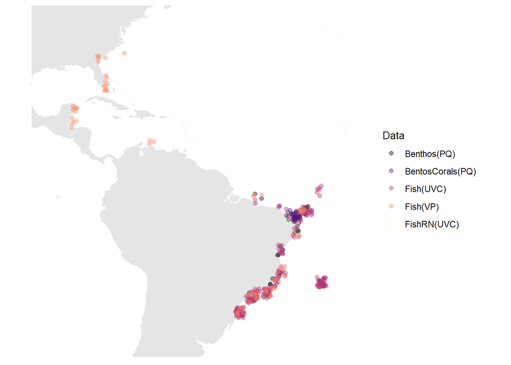

```r
# obtain coords
# aggregate coords
# with a suble jitter in long to avoid overlap of points
# note that coordinates vary at the scale of location + site
coords <- rbind (data.frame (aggregate (latitude ~ location+site+eventid,occ_Aued_et_al_sel_cols, FUN=mean,na.rm=T),
                             longitude=aggregate (longitude ~ location+site+eventid,occ_Aued_et_al_sel_cols, FUN=mean,na.rm=T)[,"longitude"],
                             Data = "Benthos(PQ)"),
                 data.frame (aggregate (latitude ~ location+site+eventid,occ_Morais_et_al_sel_cols, FUN=mean,na.rm=T),
                             longitude=aggregate (longitude ~ location+site+eventid,occ_Morais_et_al_sel_cols, FUN=mean,na.rm=T)[,"longitude"],
                             Data = "Fish(UVC)"),
                 data.frame (aggregate (latitude ~ location+site+eventid,occ_Longo_et_al_sel_cols, FUN=mean,na.rm=T),
                             longitude=aggregate (longitude ~ location+site+eventid,occ_Longo_et_al_sel_cols, FUN=mean,na.rm=T)[,"longitude"],
                             Data = "Fish(VP)"),
                 data.frame (aggregate (latitude ~ location+site+eventid,occ_Ross_et_al_sel_cols, FUN=mean,na.rm=T),
                             longitude=aggregate (longitude ~ location+site+eventid,occ_Ross_et_al_sel_cols, FUN=mean,na.rm=T)[,"longitude"],
                             Data = "FishRN(UVC)"),
                 data.frame (aggregate (latitude ~ location+site+eventid,occ_Ross_et_al_sel_cols, FUN=mean,na.rm=T),
                             longitude=aggregate (longitude ~ location+site+eventid,occ_Ross_et_al_sel_cols, FUN=mean,na.rm=T)[,"longitude"],
                             Data = "BentosCorals(PQ)")
                 )

## mapping of all sampling sites
require(ggplot2); library(ggrepel)
require("rnaturalearth");require("rnaturalearthdata")
# mapa mundi
world <- ne_countries(scale = "medium", returnclass = "sf")

# cut the map
wm <- ggplot() +
  geom_sf (data=world, size = 0.1,
           fill="gray90", colour=NA) +
  coord_sf (xlim = c(min(coords$longitude)-10,
                     max(coords$longitude)+10),
            ylim = c(max(coords$latitude)+10,
                    min(coords$latitude)-10), expand = FALSE) +

  theme_bw() + xlab(NULL) + ylab(NULL) +
  theme(panel.border = element_blank(), panel.grid.major = element_blank(), panel.grid.minor = element_blank(),
        axis.text.x = element_blank(),axis.ticks.x=element_blank(),
        axis.text.y = element_blank(),axis.ticks.y=element_blank(),
        title = element_text(size=8))

# plot aued
wm + geom_point(data=coords,
                aes(x=jitter (longitude,500),y=jitter(latitude,600), col = Data),
                    alpha=0.4,size=1.7) +

  scale_colour_viridis_d(option = "magma",
                         direction = 1) +
  theme (legend.title = element_text(size=10))
```

The data consist of 5538 unique events of sampling (i.e., video/transect within an eventid). There are 424 unique points (sites) in the map.

## EXAMPLE

```r
# let's match the datasets
occ_Longo_et_al_match<-occ_Longo_et_al_sel_cols[which(occ_Longo_et_al_sel_cols$eventid %in% occ_Aued_et_al_sel_cols$eventid ),]
occ_Aued_et_al_match<-occ_Aued_et_al_sel_cols[which(occ_Aued_et_al_sel_cols$eventid %in% occ_Longo_et_al_sel_cols$eventid ),]

# community tables
require(reshape)
# fish
comm_tab_fish <- cast (eventid ~ scientificname,
                       value = "number_of_bites",
                       fun.aggregate = sum,
                       na.rm=T,
                        data= occ_Longo_et_al_match)
# benthos
comm_tab_benthos <- cast (eventid ~ scientificname,
                       value = "cover",
                       fun.aggregate = mean,
                       na.rm=T,
                        data= occ_Aued_et_al_match)
```

The number of rows in the fish dataset is 42, and in the benthic dataset is 42. The eventids also match (all equal == T): 42

We then continue.

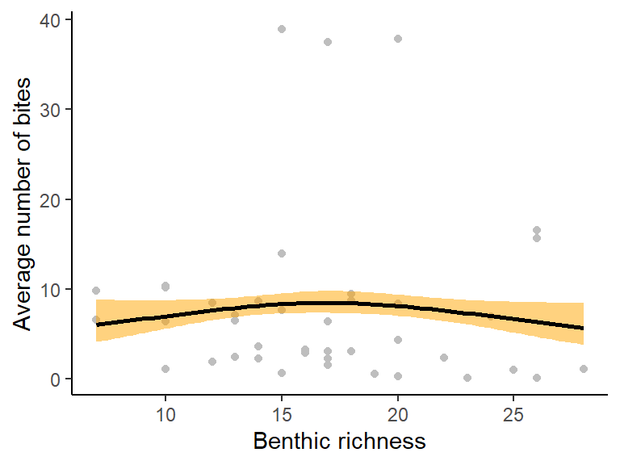

```r
# let's remove some garbage (sand, quadrat, shadow...)
to_remove_benthos <- c("areia.e.cascalho","desconhecido","quadrado","sombra")
to_remove_fish <- c("not_identified")
comm_tab_benthos <- comm_tab_benthos[,which(tolower (colnames(comm_tab_benthos)) %in% to_remove_benthos == F)]
comm_tab_fish <- comm_tab_fish[,which(tolower (colnames(comm_tab_fish)) %in% to_remove_fish == F)]

# organize data to plot
data_plot <- data.frame (eventid= comm_tab_benthos$eventid,
                         bent_rich= apply(comm_tab_benthos[,-1]>0,1,sum),
                         bites = apply(comm_tab_fish[,-1],1,mean),
                         fish_rich = apply(comm_tab_fish[,-1]>0,1,sum),
                         latitude = coords [match (comm_tab_fish$eventid, coords$eventid),"latitude"]
                          )

# fit poisson regression
poisson_smooth <- function(...) {
  geom_smooth(method = "glm", method.args = list(family = "poisson"), ...)
}

# plot
ggplot (data_plot,aes(x=bent_rich,
                 y=bites)) +
  geom_point(col= "gray") +
  poisson_smooth(
    formula = y ~ splines::ns(x, 2),
    se=T,
    #size=1,
    fill = "orange",
    colour = "black",
    alpha=0.5) +
  xlab ("Benthic richness") +
  ylab ("Average number of bites") +
  theme_classic()
```

We then continue.

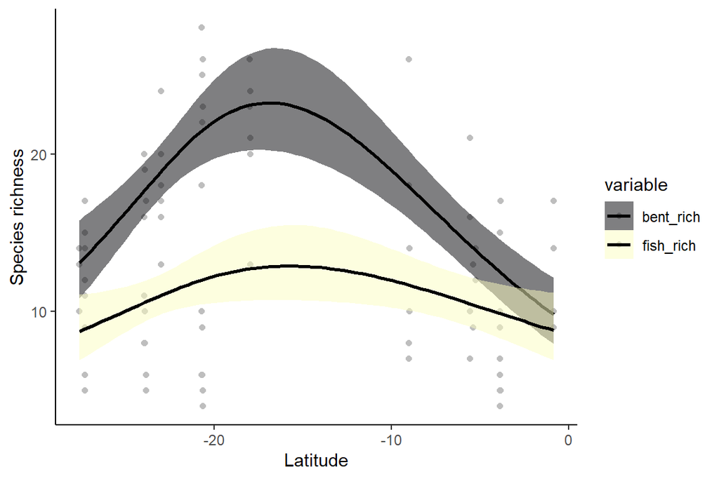

```r
# to answer the question about latitude, we need to melt the dataframe and transform it in a long format
data_plot_LF<- melt (data_plot,c("latitude", "eventid"))

# plot
ggplot (data_plot_LF[which(data_plot_LF$variable != "bites"),],
        aes(x=latitude, y=value,
                      group = variable,
            fill=variable)) +
  geom_point(col= "gray") +
  poisson_smooth(
    formula = y ~ splines::ns(x, 2),
    se=T,
    colour = "black",
    alpha=0.5) +
  xlab ("Latitude") +
  ylab ("Species richness") +
  theme_classic() +
  scale_fill_viridis_d(option="magma")
```

#### We can go farther and use the spatial information of sites to gather environmental factors from data available on the internet (e.g., BioOracle, Thyberghein et al. 2011; distance from BR coastline, data from the Brazilian Navy).

#### Sea surface temperature (SST)

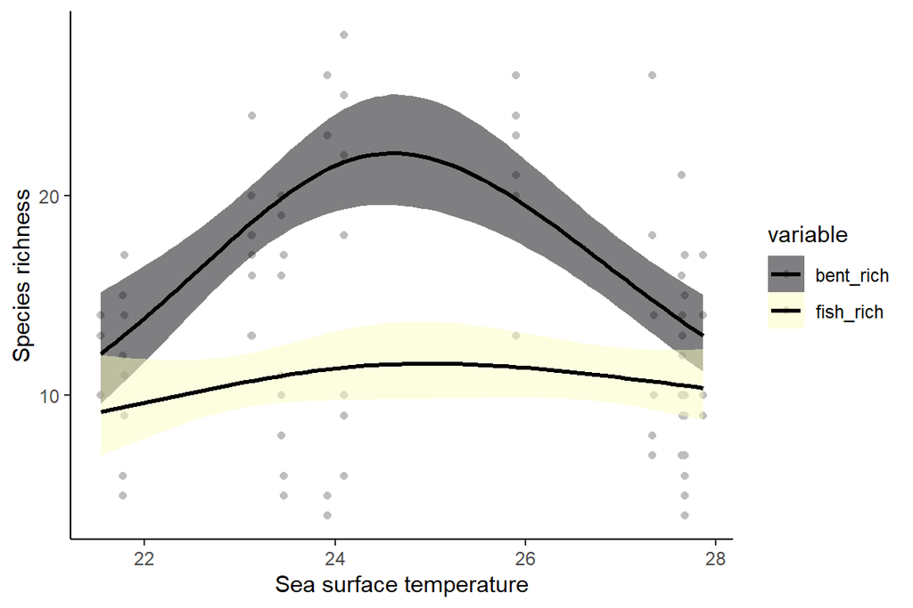

```r
# BiO Oracle - extracting covariate data
require(sdmpredictors)
layers <- list_layers()

# Download specific layers to the current directory
# set prefered folder (to download data)
dir.create (here ("Data","BioOracle"))
options(sdmpredictors_datadir=here ("Data","BioOracle"))

## chlorophil has different extent - loading and extracting in two steps
layers_oracle <- load_layers(c("BO2_tempmean_ss",
                               "BO2_ppmean_ss",
                               "BO2_salinitymean_ss",
                               "BO_damean"
                               ))

## coordinates to spatial points
spdf <- SpatialPointsDataFrame(coords = coords[,c("longitude","latitude")],
                               data = coords,
                               proj4string = CRS("+proj=longlat +datum=WGS84 +no_defs"))

## extracting data
extracted_sea_data <- extract (layers_oracle, spdf,method='simple', fun=mean)

# collating variables into the analyzed dataframe
data_plot_LF<- cbind (data_plot_LF,
                      extracted_sea_data[match(data_plot_LF$eventid, coords$eventid),]
)

# plot relative to temperature
ggplot (data_plot_LF[which(data_plot_LF$variable != "bites"),],
        aes(x=BO2_tempmean_ss, y=value,
                      group = variable,
            fill=variable)) +
  geom_point(col= "gray") +
  poisson_smooth(
    formula = y ~ splines::ns(x, 2),
    se=T,
    colour = "black",
    alpha=0.5) +
  xlab ("Sea surface temperature") +
  ylab ("Species richness") +
  theme_classic() +
  scale_fill_viridis_d(option="magma")
```

#### Distance offshore

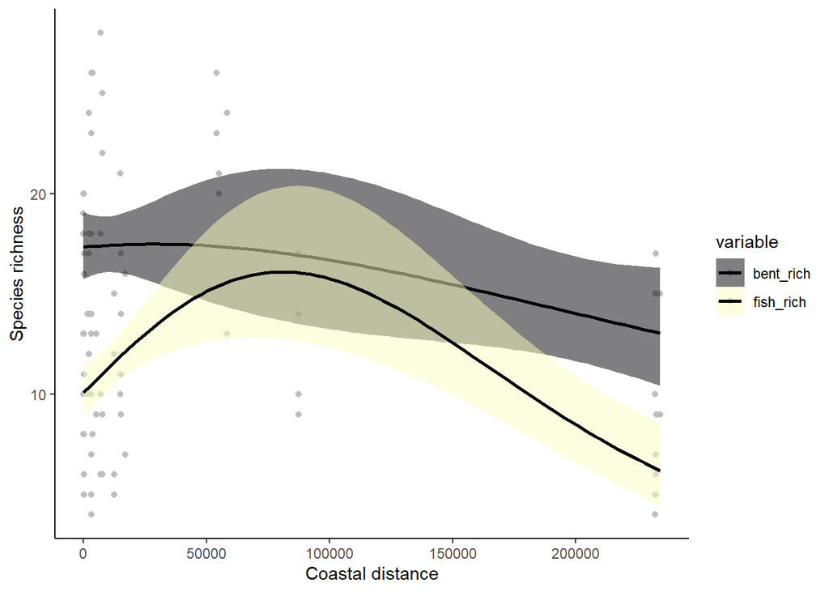

```r
# ------------------------------
#  distance offshore
# BR coastline, download from here https://mapcruzin.com/free-brazil-arcgis-maps-shapefiles.htm

#BR <- readOGR(dsn=here("Data", "brazil-coastline"), "brazil_coastline")
#crs(BR) <- "+proj=longlat +datum=WGS84 +no_defs +ellps=WGS84 +towgs84=0,0,0"
#BR <- spTransform(BR, CRS("+init=epsg:4326"))
#
## use dist2Line from geosphere - only works for WGS84
#spdf <- spTransform(spdf, CRS("+init=epsg:4326"))
#
## measuring the distance (slow -- I ran the function and saved the RData)
#dist_offshore <- geosphere::dist2Line(p = spdf,
#                             line = (BR))
## save it as it is too slow
#save (dist_offshore,file=here ("Data","brazil-coastline","extracted_distances.RData"))
load (here ("Data","brazil-coastline","extracted_distances.RData"))

# collating distance offshore into the  dataframe
data_plot_LF<- cbind (data_plot_LF,
                      distance_offshore = dist_offshore [match(data_plot_LF$eventid, coords$eventid),"distance"]
)

# plot relative to temperature
ggplot (data_plot_LF[which(data_plot_LF$variable != "bites"),],
        aes(x=distance_offshore, y=value,
                      group = variable,
            fill=variable)) +
  geom_point(col= "gray") +
  poisson_smooth(
    formula = y ~ splines::ns(x, 2),
    se=T,
    colour = "black",
    alpha=0.5) +
  xlab ("Coastal distance") +
  ylab ("Species richness") +
  theme_classic() +
  scale_fill_viridis_d(option="magma")
```

```r
# map
#wm +
#  geom_point(data=coords_sp_distance,
#             aes(x=jitter (longitude,500),y=jitter(latitude,600),
#                 col = distance)) +
#  scale_colour_viridis_c(option = "magma",
#                         direction = 1,
#                         name = "Distance Offshore") +
#  theme (legend.title = element_text(size=10),
#         legend.position = "top",
#         legend.text=element_text(size=8),
#         legend.direction = "horizontal")
#
```

More soon

**ReefSYN Working Group**